# Notebook

/meluron-codecafe

Analytical Time Complexity

**Timing Function** $T(N)$: It is the amount of time in some unit of time (say, seconds) that an algorigthm takes for a problem with input size of N.

The problems with finding such a function is that there is a lot of variability.

- Every computer's processing speed is different.
- Not all operations take same amount of time. (sqrt takes longer that basic arithmetic ops)
- There is a lot of background processes going on in the computer which also affects $T(N)$
- $T(N)$ also depends on implementation details of the algorithm, for example, we can have algorithm with similar concept but little minor improvements.

In order to solve this problem of finding out the **timing function** of an algorithm, we have a mathematical construct **Big-O Notation** for any **function**.  
**Big-O Notation** is a mathematical construct that helps us to know **blurry upper bound** of a function with respect to **input size**. We ignore **constant** and **non-dominant terms**.  
Mathematically, A function $f(N)$ is $O(g(N))$ if  
$\exists$ two constants $c$ and $N_o$ such that  
$f(N) \leq c*g(N)$ $\forall N \geq N_0$

Ex1) Find the Big-O notation for the $f(N)$ given by:  
$f(N) = 5N^2 + 3N + 2$  
Suppose that $g(N) = N^2$ then we need to find $c$ and $n_0$ such that  
$f(N) \leq c * N^2$ $\forall N \geq n_0$  
$f(N) = 5N^2 + 3N + 2 \leq 5N^2 + 3N^2 + 2N^2 = 10 * N^2$ for all $N > 1$  
$f(N) \leq 10 * g(N)$ for all $N > 1$  
Hence, we found $c$ and $n_0$ which proves that $f(N) = O(N^2)$

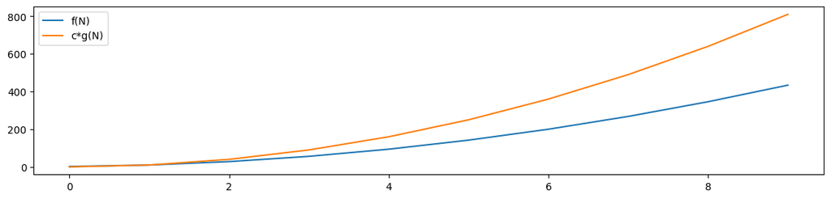

```python
import numpy as np
import matplotlib.pyplot as plt
Ns = np.arange(10)
f = 5 * Ns ** 2 + 3 * Ns + 2
c = 10
g = c * Ns ** 2
plt.figure(figsize=(14, 3))
plt.plot(f)
plt.plot(g)
plt.legend(["f(N)", "c*g(N)"])
plt.show()
```

Now let us discuss about **Big-O Notation** for **algorithm**  
Assume $T(N)$ to be the total time taken by the algorithm to run.  
We can have three cases,  
Best case ($T(N)$), Average case ($T(N)$), Worst case ($T(N)$)

We will focus more on worst case scenerio for an example algorithm that we wrote in the previous sections.

In the previous section, we wrote these algorithms for finding *sum pairs*:

- **Naive Implementation**: Here we ran two for loops, considering each for loop takes $a$ amount of time. The total time taken by the algorithm is given by  
  $T(N) = a * N^2$

Hence, for this problem, we can say that the time complexity or Big-O notation is $O(N^2)$ with the constants ($c=a$ and $N_0=0$)

- **Version 1**: Here we ran j from i+1 to len(arr) which saves us some extra compute. The total time taken by the algorithm is given by  
  $T(N) = \frac{a*N(N-1)}{2}$

For this problem, we again have the time complexity of $O(N^2)$ with the constants ($c = \frac{1}{2}$ and $N_0 = 0$)

- **Version 3**: Here we sort the arr first and loop once to check for corresponding elements. The total time taken by the algorithm is given by  
  $T(N) = a * N * \log_2(N-1) + b * N$

For this problem, we have the time complexity of $O(N \log_2(N))$ with the constants ($c = a + b$ and $N_0 = 2$)